# Thanksgiving Holiday Analysis

Fall 2024 Data Science Project

Collaborators: Austin Sankanung, Tejas Chandakkar, Jason Coates

**Contributions**:

**Austin**:

- A: Project idea

  Austin helped brainstorm possible exploratory analysis questions.
- B: Dataset Curation and Preprocessing

  Austin imported the CSV file to the dataframe and parsed it in order to turn the entries need into usable string objects.
- C: Data Exploration and Summary Statistics

  Austin explored the relation between the demographical area of respondents and how far they travelled during the Thanksgiving holiday
- E: ML Algorithm Training and Test Data Analysis

  Austin helped analyze the classification report
- F: Visualization, Result Analysis, Conclusion

  Austin helped write the result analysis and conclusion
- G: Final Tutorial Report Creation

  Austin contributed to writing the tutorial text for multiple sections and creating the GitHub Page.

**Tejas**:

- A: Project idea

  Tejas helped brainstorm initial ideas for ML analysis, and exploratory analysis questions.
- C: Data Exploration and Summary Statistics

  Tejas explored the impact that a respondent's age had on their overall household income.
- D: ML Algorithm Design/Development

  Wrote initial classification algorithm with a random forest model. Tejas also built off of Jason's data exploration question to approach this analysis model.
- E: ML Algorithm Training and Test Data Analysis

  Wrote initial model training and created a classification report
- F: Visualization, Result Analysis, Conclusion

  Wrote skeleton code for displaying the importances of our model
- G: Final Tutorial Report Creation

  Helped proofread and finalize the document

**Jason**:

- A: Project idea

  Jason found the survey data used for this project and helped brainstorm ideas for analysis of the data.
- C: Data Exploration and Summary Statistics

  Jason provided the exploratory analysis for correlation between prayer and number of pie flavors at Thanksgiving.
- D: ML Algorithm Design/Development

  Jason assisted in improving the ML algorithm to fix bugs.
- F: Visualization, Result Analysis, Conclusion

  Jason created the tree visualization for the random forest. He also wrote the part of the conclusion analyzing the perfomance of the ML algorithm.
- G: Final Tutorial Report Creation

  Jason helped proofread and finalize the document.

# Introduction

Thanksgiving is one of the most popular holidays in the United States. Every year, hundreds of millions gather with loved ones to celebrate. In this project, we're analyzing different traditions and ways people celebrate. Our goal is to analyze what factors affect how people celebrate. Doing so will help us to better understand the cultural and social dynamics of our fellow Americans.

To guide our analysis, we address the following questions:

- Does one's demographical living area affect how far they will travel for thanksgiving?
- Does household income differ across different ranges?
- Among celebrators, do those who pray have as many common pie flavors present as those who do not pray?

Thanksgiving traditions are as diverse as the individuals who celebrate them, shaped by regional, cultural, and personal influences. By examining the connections between travel patterns, living environments, household income, and other traditions, we can uncover trends and correlations that reflect broader societal dynamics. Understanding these relationships is not only academically interesting but also valuable for businesses, policymakers, and community organizers seeking to connect with or support diverse populations across America. This analysis provides a lens through which we can appreciate the variations in how this cherished holiday is experienced across different communities.

# Data Curation

Dataset:

https://github.com/fivethirtyeight/data/blob/master/thanksgiving-2015/thanksgiving-2015-poll-data.csv

In our goal to discover how Thanksgiving is celebrated across the U.S, we came across the above, a 2015 dataset containing the results of a Thanksgiving survey. This data is particularly interesting because it deals various topics related to the Thanksgiving holiday such as food, and we all love Thanksgiving food. After skimming through the data set, we saw a lot of variation in how people celebrate, so we decided to see the extent to which different households based on income, location, and average age celebrate Thanksgiving can vary. So to start, we first download the above CSV file from the Github page and upload it to the Google Colab directory for future use.

In this project, we are coding in Python using Google Colab to develop this project. The code below is some import statements for some of the main libraries we will be using throughout this tutorial.

```python
# imports
import pandas as pd
from datetime import datetime
import matplotlib.pyplot as plt
import seaborn as sns
from scipy.stats import chi2_contingency
import numpy as np
import scipy.stats as stats
```

Using the pandas library (named as 'pd') we convert the Thanksgiving csv file to a dataframe where we then display the contents.

```python
thanksgiving_df = pd.read_csv('/content/thanksgiving-2015-poll-data.csv', delimiter=',')
thanksgiving_df
```

|  | RespondentID | Do you celebrate Thanksgiving? | What is typically the main dish at your Thanksgiving dinner? | What is typically the main dish at your Thanksgiving dinner? - Other (please specify) | How is the main dish typically cooked? | How is the main dish typically cooked? - Other (please specify) | What kind of stuffing/dressing do you typically have? | What kind of stuffing/dressing do you typically have? - Other (please specify) | What type of cranberry saucedo you typically have? | What type of cranberry saucedo you typically have? - Other (please specify) | ... | Have you ever tried to meet up with hometown friends on Thanksgiving night? | Have you ever attended a "Friendsgiving?" | Will you shop any Black Friday sales on Thanksgiving Day? | Do you work in retail? | Will you employer make you work on Black Friday? | How would you describe where you live? | Age | What is your gender? | How much total combined money did all members of your HOUSEHOLD earn last year? | US Region |
| --- | --- | --- | --- | --- | --- | --- | --- | --- | --- | --- | --- | --- | --- | --- | --- | --- | --- | --- | --- | --- | --- |
| 0 | 4337954960 | Yes | Turkey | NaN | Baked | NaN | Bread-based | NaN | NaN | NaN | ... | Yes | No | No | No | NaN | Suburban | 18 - 29 | Male | $75,000 to $99,999 | Middle Atlantic |
| 1 | 4337951949 | Yes | Turkey | NaN | Baked | NaN | Bread-based | NaN | Other (please specify) | Homemade cranberry gelatin ring | ... | No | No | Yes | No | NaN | Rural | 18 - 29 | Female | $50,000 to $74,999 | East South Central |
| 2 | 4337935621 | Yes | Turkey | NaN | Roasted | NaN | Rice-based | NaN | Homemade | NaN | ... | Yes | Yes | Yes | No | NaN | Suburban | 18 - 29 | Male | $0 to $9,999 | Mountain |
| 3 | 4337933040 | Yes | Turkey | NaN | Baked | NaN | Bread-based | NaN | Homemade | NaN | ... | Yes | No | No | No | NaN | Urban | 30 - 44 | Male | $200,000 and up | Pacific |
| 4 | 4337931983 | Yes | Tofurkey | NaN | Baked | NaN | Bread-based | NaN | Canned | NaN | ... | Yes | No | No | No | NaN | Urban | 30 - 44 | Male | $100,000 to $124,999 | Pacific |
| ... | ... | ... | ... | ... | ... | ... | ... | ... | ... | ... | ... | ... | ... | ... | ... | ... | ... | ... | ... | ... | ... |
| 1053 | 4335944082 | Yes | Turkey | NaN | Roasted | NaN | Bread-based | NaN | Homemade | NaN | ... | Yes | Yes | No | No | NaN | Rural | 30 - 44 | Female | $100,000 to $124,999 | Mountain |
| 1054 | 4335943173 | Yes | Turkey | NaN | Baked | NaN | Bread-based | NaN | Canned | NaN | ... | No | No | No | No | NaN | Suburban | 60+ | Female | $50,000 to $74,999 | Pacific |
| 1055 | 4335943060 | Yes | Other (please specify) | Duck | Baked | NaN | Rice-based | NaN | NaN | NaN | ... | Yes | Yes | Yes | No | NaN | Urban | 60+ | Male | $100,000 to $124,999 | Pacific |
| 1056 | 4335934708 | Yes | Turkey | NaN | Baked | NaN | NaN | NaN | Homemade | NaN | ... | Yes | No | Yes | Yes | Yes | NaN | NaN | NaN | NaN | NaN |
| 1057 | 4335894916 | Yes | Turkey | NaN | Baked | NaN | Bread-based | NaN | Canned | NaN | ... | Yes | Yes | Yes | No | NaN | NaN | NaN | NaN | NaN | NaN |

1058 rows × 65 columns

Next, we print out each data type for every column in the dataframe. We see that every column except for the first one is of type object. In order to make the entries easier to use, we change the entries from a object to a string in order to make proccessing the values easier.

```python
print(thanksgiving_df.dtypes)
```

```
RespondentID                                                                              int64
Do you celebrate Thanksgiving?                                                           object
What is typically the main dish at your Thanksgiving dinner?                             object
What is typically the main dish at your Thanksgiving dinner? - Other (please specify)    object
How is the main dish typically cooked?                                                   object
                                                                                          ...
How would you describe where you live?                                                   object
Age                                                                                      object
What is your gender?                                                                     object
How much total combined money did all members of your HOUSEHOLD earn last year?          object
US Region                                                                                object
Length: 65, dtype: object
```

```python
# change object dtypes to string
thanksgiving_df = thanksgiving_df.apply(lambda col: col.astype('string') if col.dtypes == 'object' else col)
print(thanksgiving_df.dtypes)
```

```
RespondentID                                                                                      int64
Do you celebrate Thanksgiving?                                                           string[python]
What is typically the main dish at your Thanksgiving dinner?                             string[python]
What is typically the main dish at your Thanksgiving dinner? - Other (please specify)    string[python]
How is the main dish typically cooked?                                                   string[python]
                                                                                              ...
How would you describe where you live?                                                   string[python]
Age                                                                                      string[python]
What is your gender?                                                                     string[python]
How much total combined money did all members of your HOUSEHOLD earn last year?          string[python]
US Region                                                                                string[python]
Length: 65, dtype: object
```

# Exploratory Data Analysis

# Does one's demographical living area affect how far they will travel for thanksgiving?

Using Chi-square,

H0: There is no association between where people live and how far they travel for Thanksgiving.

Ha: There is an association between where people live now and how far they travel for Thanksgiving.

To help answer this question, we will create a subset of the data using the "RespondentID", "How would you describe where you live?", and "How far will you travel for Thanksgiving?" columns from the thanksgiving_df dataFrame. Next we drop any rows with the entry ‘NaN’ (this signifies missing values) to clean the subset before using it. Lastly, we display 14 rows to help visualize what the newly created subset is structured like.

```python
austin_df = thanksgiving_df[["RespondentID", "How would you describe where you live?", "How far will you travel for Thanksgiving?"]].dropna()
print(austin_df.head(14))
```

```
    RespondentID How would you describe where you live?  \
0     4337954960                               Suburban
1     4337951949                                  Rural
2     4337935621                               Suburban
3     4337933040                                  Urban
4     4337931983                                  Urban
5     4337929779                                  Urban
6     4337924420                                  Rural
7     4337916002                                  Rural
8     4337914977                                  Urban
9     4337899817                               Suburban
11    4337893416                               Suburban
12    4337888291                               Suburban
13    4337878450                                  Urban
14    4337878351                                  Rural
```

[output cut: 16 more lines]

By using the Pandas library we can create a contingency table for the "How would you describe where you live?" and "How far will you travel for Thanksgiving?" columns of the subset data frame. We are able to now find the P-value and plot the travel distances based on whether respondents live in urban, suburban, or rural areas.

```python
contingency_table = pd.crosstab(austin_df["How would you describe where you live?"], austin_df["How far will you travel for Thanksgiving?"])
contingency_table
```

| How far will you travel for Thanksgiving? How would you describe where you live? | Thanksgiving is happening at my home--I won't travel at all | Thanksgiving is local--it will take place in the town I live in | Thanksgiving is out of town and far away--I have to drive several hours or fly | Thanksgiving is out of town but not too far--it's a drive of a few hours or less |
| --- | --- | --- | --- | --- |
| Rural | 102 | 50 | 20 | 44 |
| Suburban | 204 | 138 | 44 | 110 |
| Urban | 89 | 87 | 18 | 42 |

```python
chi2, p, dof, expected = chi2_contingency(contingency_table)
print(f"P-value: {p}")
```

```
P-value: 0.05678248731935149
```

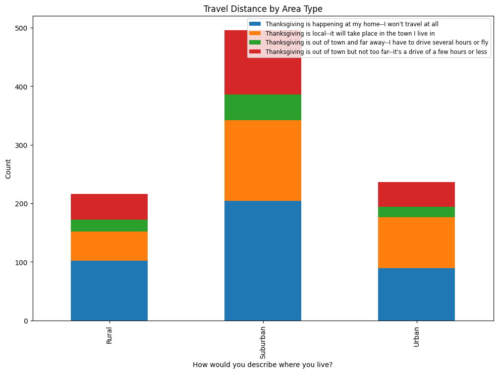

```python
plt.figure(figsize=(12, 8))
contingency_table.plot(kind='bar', stacked=True, ax=plt.gca())
plt.title('Travel Distance by Area Type')
plt.ylabel('Count')
plt.legend(fontsize='small')
plt.show()
```

Findings:

The p-value from the Chi-Square test is about 0.0568. With a significance level (alpha) of 0.05, we fail to reject the null hypothesis at the 0.05 signifcance level since the P-value is greater than alpha. Therefore we can conclude there is no significant association between where people live and how far they travel for Thanksgiving.

# Does household income differ across different ranges?

### Ho: The mean income is the same across different age ranges

### Ha: At least one age range has a different mean income from the others

Since we want to check if a person's age range has an impact on how much their household income is, we want to see if there is a correlation between the two categories. This is best done with an ANOVA test which we will conduct in the upcoming cells.

```python
# Here we are cleaning up the columns we want to use for this test
df = thanksgiving_df
df = df.dropna(subset=['Age', 'How much total combined money did all members of your HOUSEHOLD earn last year?'])
df['Age'] = df['Age'].str.strip()
df['Age'] = df['Age'].astype('category')
print(df['Age'].unique())
```

```
['18 - 29', '30 - 44', '60+', '45 - 59']
Categories (4, string): [18 - 29, 30 - 44, 45 - 59, 60+]
```

```python
# This function will calculate a midpoint in a certain range which will help us gather numerical data for our test
def range_mdpt(income_range):
    # If they prefer not to say, we add a null value
    if 'Prefer' in income_range:
      return np.nan
    income_range = income_range.replace('$', '').replace(',', '').strip()

    # We set the lower bound if we have an unbounded range
    if 'and up' in income_range:
        lower_bound = int(income_range.split(' ')[0])
        upper_bound = lower_bound

    # Otherwise, we get the average of the upper and lower bound of the range
    else:
        income_range = income_range.split(' to ')
        lower_bound = int(income_range[0])
        upper_bound = int(income_range[1])

    return (lower_bound + upper_bound) / 2

df['household_income'] = df['How much total combined money did all members of your HOUSEHOLD earn last year?'].apply(range_mdpt)
df = df.dropna(subset=['Age', 'household_income'])

print(df[['How much total combined money did all members of your HOUSEHOLD earn last year?', 'household_income']])
```

```
     How much total combined money did all members of your HOUSEHOLD earn last year?  \
0                                    $75,000 to $99,999
1                                    $50,000 to $74,999
2                                          $0 to $9,999
3                                       $200,000 and up
4                                  $100,000 to $124,999
...                                                 ...
1051                               $125,000 to $149,999
1052                                       $0 to $9,999
1053                               $100,000 to $124,999
1054                                 $50,000 to $74,999
1055                               $100,000 to $124,999

      household_income
0              87499.5
1              62499.5
2               4999.5
3             200000.0
4             112499.5
...                ...
1051          137499.5
1052            4999.5
1053          112499.5
1054           62499.5
1055          112499.5

[889 rows x 2 columns]
```

```python
# We want to see how many people we have in each group to ensure our samples will create representative results
group_sizes = df.groupby('Age')['household_income'].count()
print(group_sizes)
```

```
Age
18 - 29    171
30 - 44    225
45 - 59    258
60+        235
Name: household_income, dtype: int64
```

```python
# We run the ANOVA test and get our p-value
income_by_age_range = [df['household_income'][df['Age'] == age_group] for age_group in df['Age'].unique()]
anova_result = stats.f_oneway(*income_by_age_range)
print(f"ANOVA Result: F-statistic = {anova_result.statistic}, p-value = {anova_result.pvalue}")
```

```
ANOVA Result: F-statistic = 35.51093763888391, p-value = 1.126909438442879e-21
```

This incredibly low p-value tells us that there is a significant impact between our two categories and allows us to reject the null hypothesis as our p-value is smaller than 0.5. Lets look at a graph distribution of our data to further this point.

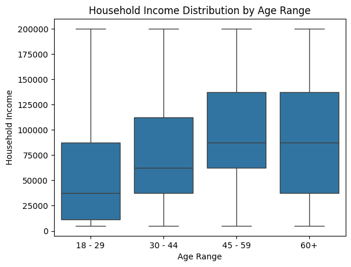

```python
# We create a boxplot and stack each side by side for easy readable comparison
sns.boxplot(x='Age', y='household_income', data=df)
plt.title('Household Income Distribution by Age Range')
plt.xlabel('Age Range')
plt.ylabel('Household Income')
plt.show()
```

This graph further shows us that as the age ranges increase, the medians household incomes increase until they even out by the 45-59 and 60+ ranges. Overall, we can conclude that there is a significant correlation between the two categories.

# Among celebrators, do those who pray have as many common pie flavors present as those who do not pray?

Ho: Prayers and non-prayers have the same number of common pie flavors present at their Thanksgiving.

Ha: Prayers and non-prayers have a different number of common pie flavors present at their Thanksgiving.

Since we are comparing two sample means, we will conduct a two sample t-test to prove or disprove our null hypothesis.

```python
#isolate those who celbrate Thanksgiving and then include only the relevant features
mask = thanksgiving_df["Do you celebrate Thanksgiving?"] == "Yes"
pie_df = thanksgiving_df[mask]
pie_df = thanksgiving_df[["Do you typically pray before or after the Thanksgiving meal?",
                          "Which type of pie is typically served at your Thanksgiving dinner? Please select all that apply. - Apple",
                          "Which type of pie is typically served at your Thanksgiving dinner? Please select all that apply. - Buttermilk",
                          "Which type of pie is typically served at your Thanksgiving dinner? Please select all that apply. - Cherry",
                          "Which type of pie is typically served at your Thanksgiving dinner? Please select all that apply. - Chocolate",
                          "Which type of pie is typically served at your Thanksgiving dinner? Please select all that apply. - Coconut cream",
                          "Which type of pie is typically served at your Thanksgiving dinner? Please select all that apply. - Key lime",
                          "Which type of pie is typically served at your Thanksgiving dinner? Please select all that apply. - Peach",
                          "Which type of pie is typically served at your Thanksgiving dinner? Please select all that apply. - Pecan",
                          "Which type of pie is typically served at your Thanksgiving dinner? Please select all that apply. - Pumpkin",
                          "Which type of pie is typically served at your Thanksgiving dinner? Please select all that apply. - Sweet Potato"]]
pie_df
```

|  | Do you typically pray before or after the Thanksgiving meal? | Which type of pie is typically served at your Thanksgiving dinner? Please select all that apply. - Apple | Which type of pie is typically served at your Thanksgiving dinner? Please select all that apply. - Buttermilk | Which type of pie is typically served at your Thanksgiving dinner? Please select all that apply. - Cherry | Which type of pie is typically served at your Thanksgiving dinner? Please select all that apply. - Chocolate | Which type of pie is typically served at your Thanksgiving dinner? Please select all that apply. - Coconut cream | Which type of pie is typically served at your Thanksgiving dinner? Please select all that apply. - Key lime | Which type of pie is typically served at your Thanksgiving dinner? Please select all that apply. - Peach | Which type of pie is typically served at your Thanksgiving dinner? Please select all that apply. - Pecan | Which type of pie is typically served at your Thanksgiving dinner? Please select all that apply. - Pumpkin | Which type of pie is typically served at your Thanksgiving dinner? Please select all that apply. - Sweet Potato |
| --- | --- | --- | --- | --- | --- | --- | --- | --- | --- | --- | --- |
| 0 | Yes | Apple | <NA> | <NA> | <NA> | <NA> | <NA> | <NA> | <NA> | <NA> | <NA> |
| 1 | Yes | Apple | <NA> | <NA> | Chocolate | <NA> | <NA> | <NA> | <NA> | Pumpkin | <NA> |
| 2 | Yes | Apple | <NA> | Cherry | <NA> | <NA> | <NA> | Peach | Pecan | Pumpkin | Sweet Potato |
| 3 | No | <NA> | <NA> | <NA> | <NA> | <NA> | <NA> | <NA> | Pecan | Pumpkin | <NA> |
| 4 | No | Apple | <NA> | <NA> | <NA> | <NA> | <NA> | <NA> | <NA> | Pumpkin | <NA> |
| ... | ... | ... | ... | ... | ... | ... | ... | ... | ... | ... | ... |
| 1053 | No | <NA> | <NA> | <NA> | <NA> | <NA> | <NA> | <NA> | Pecan | Pumpkin | Sweet Potato |
| 1054 | No | <NA> | <NA> | <NA> | <NA> | <NA> | <NA> | <NA> | <NA> | Pumpkin | <NA> |
| 1055 | Yes | Apple | <NA> | <NA> | <NA> | <NA> | <NA> | <NA> | <NA> | <NA> | <NA> |
| 1056 | Yes | <NA> | <NA> | <NA> | <NA> | Coconut cream | <NA> | <NA> | <NA> | <NA> | <NA> |
| 1057 | Yes | <NA> | <NA> | <NA> | Chocolate | <NA> | <NA> | <NA> | <NA> | <NA> | <NA> |

1058 rows × 11 columns

```python
#create a new column to contain the number of common pie flavors, then count the number for each row
pie_df["Number of Common Pie Flavors"] = pie_df.iloc[:, 1:].apply(lambda row: row.count(), axis=1)
pie_df
```

|  | Do you typically pray before or after the Thanksgiving meal? | Which type of pie is typically served at your Thanksgiving dinner? Please select all that apply. - Apple | Which type of pie is typically served at your Thanksgiving dinner? Please select all that apply. - Buttermilk | Which type of pie is typically served at your Thanksgiving dinner? Please select all that apply. - Cherry | Which type of pie is typically served at your Thanksgiving dinner? Please select all that apply. - Chocolate | Which type of pie is typically served at your Thanksgiving dinner? Please select all that apply. - Coconut cream | Which type of pie is typically served at your Thanksgiving dinner? Please select all that apply. - Key lime | Which type of pie is typically served at your Thanksgiving dinner? Please select all that apply. - Peach | Which type of pie is typically served at your Thanksgiving dinner? Please select all that apply. - Pecan | Which type of pie is typically served at your Thanksgiving dinner? Please select all that apply. - Pumpkin | Which type of pie is typically served at your Thanksgiving dinner? Please select all that apply. - Sweet Potato | Number of Common Pie Flavors |
| --- | --- | --- | --- | --- | --- | --- | --- | --- | --- | --- | --- | --- |
| 0 | Yes | Apple | <NA> | <NA> | <NA> | <NA> | <NA> | <NA> | <NA> | <NA> | <NA> | 1 |
| 1 | Yes | Apple | <NA> | <NA> | Chocolate | <NA> | <NA> | <NA> | <NA> | Pumpkin | <NA> | 3 |
| 2 | Yes | Apple | <NA> | Cherry | <NA> | <NA> | <NA> | Peach | Pecan | Pumpkin | Sweet Potato | 6 |
| 3 | No | <NA> | <NA> | <NA> | <NA> | <NA> | <NA> | <NA> | Pecan | Pumpkin | <NA> | 2 |
| 4 | No | Apple | <NA> | <NA> | <NA> | <NA> | <NA> | <NA> | <NA> | Pumpkin | <NA> | 2 |
| ... | ... | ... | ... | ... | ... | ... | ... | ... | ... | ... | ... | ... |
| 1053 | No | <NA> | <NA> | <NA> | <NA> | <NA> | <NA> | <NA> | Pecan | Pumpkin | Sweet Potato | 3 |
| 1054 | No | <NA> | <NA> | <NA> | <NA> | <NA> | <NA> | <NA> | <NA> | Pumpkin | <NA> | 1 |
| 1055 | Yes | Apple | <NA> | <NA> | <NA> | <NA> | <NA> | <NA> | <NA> | <NA> | <NA> | 1 |
| 1056 | Yes | <NA> | <NA> | <NA> | <NA> | Coconut cream | <NA> | <NA> | <NA> | <NA> | <NA> | 1 |
| 1057 | Yes | <NA> | <NA> | <NA> | Chocolate | <NA> | <NA> | <NA> | <NA> | <NA> | <NA> | 1 |

1058 rows × 12 columns

```python
#calculate variance for those who pray at Thanksgiving and those who don't
prayers = pie_df[pie_df["Do you typically pray before or after the Thanksgiving meal?"] == "Yes"]
non_prayers = pie_df[pie_df["Do you typically pray before or after the Thanksgiving meal?"] == "No"]
print(np.var(prayers["Number of Common Pie Flavors"]), np.var(non_prayers["Number of Common Pie Flavors"]))
```

```
1.5913435856344476 1.2703586544887495
```

```python
#run a ttest on the data
stats.ttest_ind(prayers["Number of Common Pie Flavors"], non_prayers["Number of Common Pie Flavors"])
```

```
TtestResult(statistic=4.495989801482408, pvalue=7.772730583596832e-06, df=957.0)
```

**Conclusion:** Because our p-value of 7.772730583596832e-06 is well below 0.05, we can confidently reject our null hypothesis. There is statistically significant evidence to conclude that prayers and non-prayers have a different number of common pie flavors present at their Thanksgivings.

```python
#print the mean number of pie flavors for each group
print(prayers["Number of Common Pie Flavors"].mean(), non_prayers["Number of Common Pie Flavors"].mean())
```

```
2.3349358974358974 1.964179104477612
```

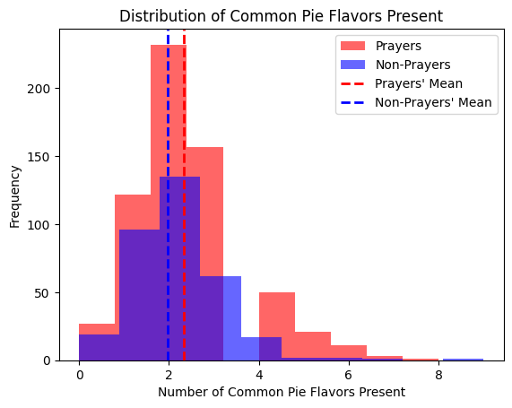

```python
#create a double histogram displaying the numbers of pie flavors for each group
plt.hist(prayers["Number of Common Pie Flavors"], label='Prayers', alpha=.6, color='red')
plt.hist(non_prayers["Number of Common Pie Flavors"], label='Non-Prayers', alpha=.6, color='blue')
plt.axvline(prayers["Number of Common Pie Flavors"].mean(), color='r', linestyle='dashed', linewidth=2, label="Prayers' Mean")
plt.axvline(non_prayers["Number of Common Pie Flavors"].mean(), color='b', linestyle='dashed', linewidth=2, label="Non-Prayers' Mean")
plt.legend()
plt.title('Distribution of Common Pie Flavors Present')
plt.xlabel('Number of Common Pie Flavors Present')
plt.ylabel('Frequency')
plt.show()
```

As we can see by the double histogram, those who pray on Thanksgiving tend to have a higher number of common pie flavors present than those who do not pray.

# Primary Analysis

We would like to build a model using classification that will tell us if people that pray have as many common pie flavors as people that dont pray. Through this, we will be able to predict whether or not a person prays based on the presence of certain pie flavors.

```python
#First let's see what our data currently looks like
pie_df.head()
```

|  | Do you typically pray before or after the Thanksgiving meal? | Which type of pie is typically served at your Thanksgiving dinner? Please select all that apply. - Apple | Which type of pie is typically served at your Thanksgiving dinner? Please select all that apply. - Buttermilk | Which type of pie is typically served at your Thanksgiving dinner? Please select all that apply. - Cherry | Which type of pie is typically served at your Thanksgiving dinner? Please select all that apply. - Chocolate | Which type of pie is typically served at your Thanksgiving dinner? Please select all that apply. - Coconut cream | Which type of pie is typically served at your Thanksgiving dinner? Please select all that apply. - Key lime | Which type of pie is typically served at your Thanksgiving dinner? Please select all that apply. - Peach | Which type of pie is typically served at your Thanksgiving dinner? Please select all that apply. - Pecan | Which type of pie is typically served at your Thanksgiving dinner? Please select all that apply. - Pumpkin | Which type of pie is typically served at your Thanksgiving dinner? Please select all that apply. - Sweet Potato | Number of Common Pie Flavors |
| --- | --- | --- | --- | --- | --- | --- | --- | --- | --- | --- | --- | --- |
| 0 | Yes | Apple | <NA> | <NA> | <NA> | <NA> | <NA> | <NA> | <NA> | <NA> | <NA> | 1 |
| 1 | Yes | Apple | <NA> | <NA> | Chocolate | <NA> | <NA> | <NA> | <NA> | Pumpkin | <NA> | 3 |
| 2 | Yes | Apple | <NA> | Cherry | <NA> | <NA> | <NA> | Peach | Pecan | Pumpkin | Sweet Potato | 6 |
| 3 | No | <NA> | <NA> | <NA> | <NA> | <NA> | <NA> | <NA> | Pecan | Pumpkin | <NA> | 2 |
| 4 | No | Apple | <NA> | <NA> | <NA> | <NA> | <NA> | <NA> | <NA> | Pumpkin | <NA> | 2 |

```python
#Now lets import what we'll need to conduct our ML analysis
import pandas as pd
from sklearn.model_selection import train_test_split
from sklearn.linear_model import LogisticRegression
from sklearn.metrics import accuracy_score, classification_report, confusion_matrix
import seaborn as sns
import matplotlib.pyplot as plt
from sklearn.ensemble import RandomForestClassifier
```

```python
#Let's remap our data using one hot encoding to make it more useful
pie_df.loc[:, "Pray_Binary"] = pie_df["Do you typically pray before or after the Thanksgiving meal?"].map({"Yes": 1, "No": 0})
pie_df = pie_df.dropna(subset=["Pray_Binary"])
pie_columns = [col for col in pie_df.columns if "Which type of pie" in col]
for col in pie_columns:
    pie_df[col] = pie_df[col].notna().astype(int)

#lets set our x and y variables for ML analysis
X = pie_df[pie_columns]
y = pie_df["Pray_Binary"]
```

[output not shown]

[output cut: 11 more lines]

[output not shown]

```python
#Check what our data looks like now to ensure the one hot encoding worked
pie_df.head()
```

|  | Do you typically pray before or after the Thanksgiving meal? | Which type of pie is typically served at your Thanksgiving dinner? Please select all that apply. - Apple | Which type of pie is typically served at your Thanksgiving dinner? Please select all that apply. - Buttermilk | Which type of pie is typically served at your Thanksgiving dinner? Please select all that apply. - Cherry | Which type of pie is typically served at your Thanksgiving dinner? Please select all that apply. - Chocolate | Which type of pie is typically served at your Thanksgiving dinner? Please select all that apply. - Coconut cream | Which type of pie is typically served at your Thanksgiving dinner? Please select all that apply. - Key lime | Which type of pie is typically served at your Thanksgiving dinner? Please select all that apply. - Peach | Which type of pie is typically served at your Thanksgiving dinner? Please select all that apply. - Pecan | Which type of pie is typically served at your Thanksgiving dinner? Please select all that apply. - Pumpkin | Which type of pie is typically served at your Thanksgiving dinner? Please select all that apply. - Sweet Potato | Number of Common Pie Flavors | Pray_Binary |
| --- | --- | --- | --- | --- | --- | --- | --- | --- | --- | --- | --- | --- | --- |
| 0 | Yes | 1 | 0 | 0 | 0 | 0 | 0 | 0 | 0 | 0 | 0 | 1 | 1.0 |
| 1 | Yes | 1 | 0 | 0 | 1 | 0 | 0 | 0 | 0 | 1 | 0 | 3 | 1.0 |
| 2 | Yes | 1 | 0 | 1 | 0 | 0 | 0 | 1 | 1 | 1 | 1 | 6 | 1.0 |
| 3 | No | 0 | 0 | 0 | 0 | 0 | 0 | 0 | 1 | 1 | 0 | 2 | 0.0 |
| 4 | No | 1 | 0 | 0 | 0 | 0 | 0 | 0 | 0 | 1 | 0 | 2 | 0.0 |

```python
#This will help balance our data by undersampling the majority: those who pray on Thanksgiving
#This is useful because it will reduce bias in our model
from imblearn.under_sampling import RandomUnderSampler

rus = RandomUnderSampler(random_state=42)
X_resampled, y_resampled = rus.fit_resample(X, y)
```

```python
#Train and evaluate the random forest classifier
X_train, X_test, y_train, y_test = train_test_split(X_resampled, y_resampled, test_size=0.3, random_state=42)
clf = RandomForestClassifier(random_state=42, class_weight = 'balanced')
clf.fit(X_train, y_train)

y_pred = clf.predict(X_test)
print(classification_report(y_test, y_pred))
```

```
              precision    recall  f1-score   support

         0.0       0.57      0.79      0.66       105
         1.0       0.61      0.35      0.45        96

    accuracy                           0.58       201
   macro avg       0.59      0.57      0.56       201
weighted avg       0.59      0.58      0.56       201
```

# Visualization

First lets visualize our random forest.

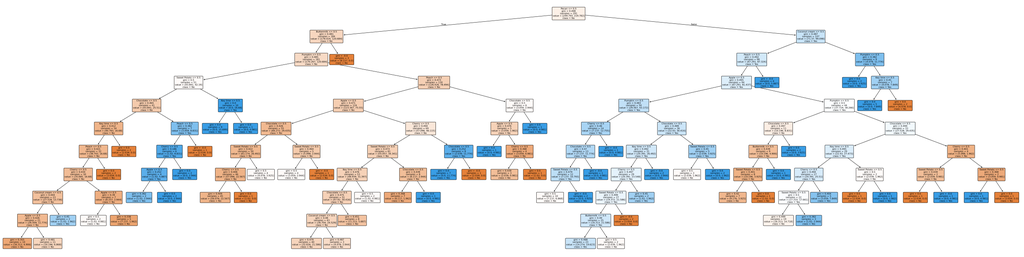

```python
#Clean the feature names
clean_feature_names = [name.split("- ")[-1] for name in X.columns]

#import necessary functions
from sklearn.tree import plot_tree
import matplotlib.pyplot as plt
#Draw tree using plot_tree
plt.figure(figsize=(64, 16), dpi=200)
plot_tree(clf.estimators_[0], feature_names=clean_feature_names, class_names=['No', 'Yes'], filled=True, rounded=True, fontsize=8)
plt.show()
```

Now lets visualize how important each feature was in our learning model.

```
[0.11753238 0.04574472 0.12207787 0.12357523 0.07569861 0.05483318
 0.06877494 0.12366271 0.15062241 0.11747795]
```

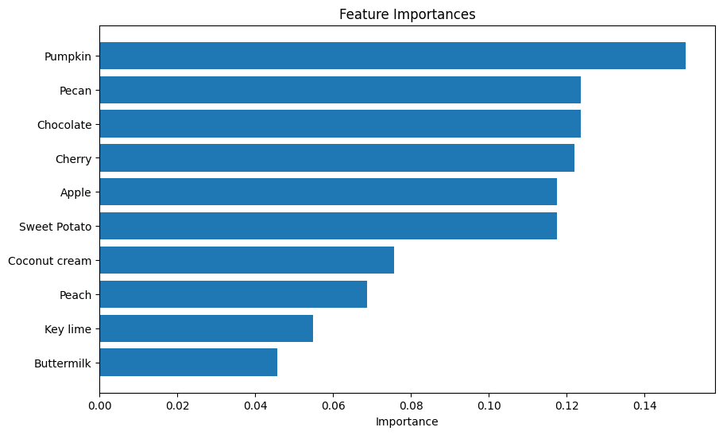

```python
importances = clf.feature_importances_
print(importances)
#Get the names of the features
feature_names = X_train.columns

#Sort the importances in descending order
indices = np.argsort(importances)

#Clean the feature names
clean_feature_names = [name.split("- ")[-1] for name in feature_names]

#Plot the feature importances
plt.figure(figsize=(10, 6))
plt.title("Feature Importances")
plt.barh(range(len(indices)), importances[indices], align="center")
plt.yticks(range(len(indices)), [clean_feature_names[i] for i in indices])
plt.xlabel("Importance")
plt.show()
```

# Insights and Conclusion

First let's recall the results of our machine learning model, and analyze its level of success.

```python
print(classification_report(y_test, y_pred))
```

```
              precision    recall  f1-score   support

         0.0       0.57      0.79      0.66       105
         1.0       0.61      0.35      0.45        96

    accuracy                           0.58       201
   macro avg       0.59      0.57      0.56       201
weighted avg       0.59      0.58      0.56       201
```

Our model is 58% accurate, a moderate level of accuracy. This tells us that the model did decently well, and it correctly guesses more often than not. However, this model still has room for improvement. Looking specifically at instances of those who pray before or after their meal, we see the model struggles somewhat. Our recall value of 0.35 for our 1.0 class is a particular concern. This value shows that the model identified only 35% of those who actually responded that they pray. Our model is much better for predicting those who do not pray, as compared to predicting those who do.

Now let's consider the implications of our model's findings. By looking at the feature importances bar graph, the presence or non-presence of pumpkin pie was the most important feature in our model as about 15% of our model’s decision was affected by it. On the other hand, flavors like Buttermilk and Key Lime had the least influence of about 4.5% and 5.5% respectively. However, the range for the feature importances is roughly a little more than 10%. This shows that one feature was not unproportionally more significant than another.

Each respondent's diverse liking to different types of pie mirrors the diverse American population who celebrate Thanksgiving and their different traditions when celebrating this national holiday. So despite the fact that gatherings may or may involve prayers, we can all be thankful for our favorite types of pie and classification machine learning.